# R Notebook

In this blog, I’d like to show you the concepts of absolute error and relative error when estimating probabilities from simulation.

Absolute error is the magnitude of the difference between the exact value and the approximation. Relative error is the absolute error divided by the magnitude of the exact value.

In the simulation, I performed a 14 X 5 factorial experiment simulation that estimates the error for each combination of replicate number ($2^{2}$, $2^{3}$, ., $2^{15}$) and probability (0.01, 0.05, 0.10, 0.25, 0.50).

We can star with doing one series of simulation with p = .50. First, We made two vectors that can store absolute error and relative error. Then, we did for loop to get the value of abs_error and rel_error in each condition. We found that as N increase, absolute error and relative error both decrease.

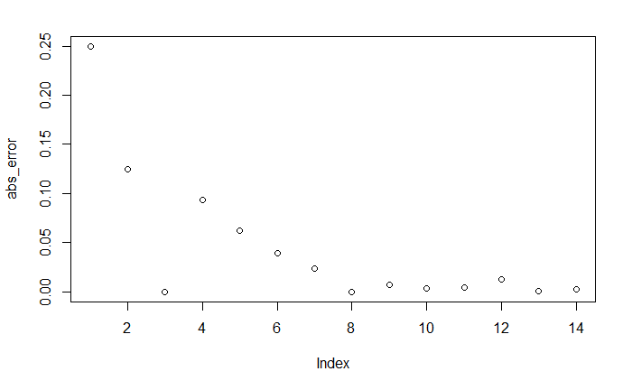

```r
set.seed(123)
p <- .50
abs_error <- rel_error <- rep(NA, 14)
n = 2
for (i in seq_along(abs_error)) {
  n = n * 2
  p_hat <- rbinom(1, n, p)/n
  abs_error[i] <- abs(p - p_hat)
  rel_error[i] <- abs_error[i]/p
}
plot(abs_error)
```

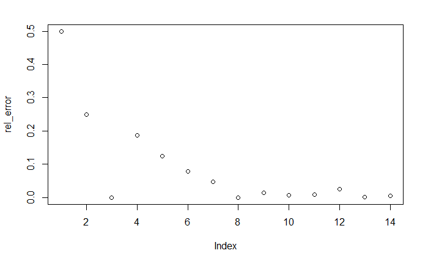

```r
plot(rel_error)
```

After generating one plot, now we start to do the simulation with multiple p values. Different from previous method, here I created two matrices with 5 rows and 14 columns to store the abs_errors and rel_errors. The code is demonstrated below. In the first for loop, j represented probability choices. In the second loop, i can control the simulation times. Most interestingly, I added one more loop, which could enable us to get the stable probability of abs_error and rel_error in one series of simulation.

```r
# method 1
set.seed(10)
p <- c(.50, .25, .10, .05, .01)
abs_error <- rel_error <- matrix(nrow = 5, ncol = 14)
for (j in seq(1, 5)) {
  n = 2
  for (i in seq(1, 14)) {
    n <- n * 2
    tmp_abs_error <- 0
    for (k in seq(1, 1000)) {
      p_hat <- rbinom(1, n, p[j])/n
      tmp_abs_error <- tmp_abs_error + abs(p[j] - p_hat)
    }

    abs_error[j,i] <- tmp_abs_error/1000
    rel_error[j,i] <- abs_error[j,i]/p[j]
  }
}
```

```r
# method 2
p <- c(.50, .25, .10, .05, .01)
abs_error <- rel_error <- matrix(nrow = 5, ncol = 14)
for (j in seq(1, 5)) {
  n = 2
  for (i in seq(1, 14)) {
    n <- n * 2
    abs_error[j,i] <- mean(abs(rbinom(1000, n, p[j])/n - p[j]))
    rel_error[j,i] <- abs_error[j,i]/p[j]
  }
}
```

The scatter plot are shown below. We can find that with N increase, absolute error will decrease. And the larger the p value, the larger absolute error it is.

```r
label <- c(2^2, 2^3, 2^4, 2^5,2^6, 2^7, 2^8, 2^9, 2^10, 2^11, 2^12, 2^13, 2^14, 2^15)
plot(abs_error[1,], col = "orange", type = "b", xaxt = "n", xlab = ("N"~(log[2]~"scale")), ylab = "Absolute Error", pch=16, lwd = 4)
axis(1, at = 1:14, labels = label, las = 2)
```

```r
lines(abs_error[2,], col = "purple", type = "b", pch=16, lwd = 4)
lines(abs_error[3,], col = "green", type = "b", pch=16, lwd = 4)
```

```r
lines(abs_error[4,], col = "blue", type = "b", pch=16, lwd = 4)
lines(abs_error[5,], col = "red", type = "b", pch=16, lwd = 4)
```

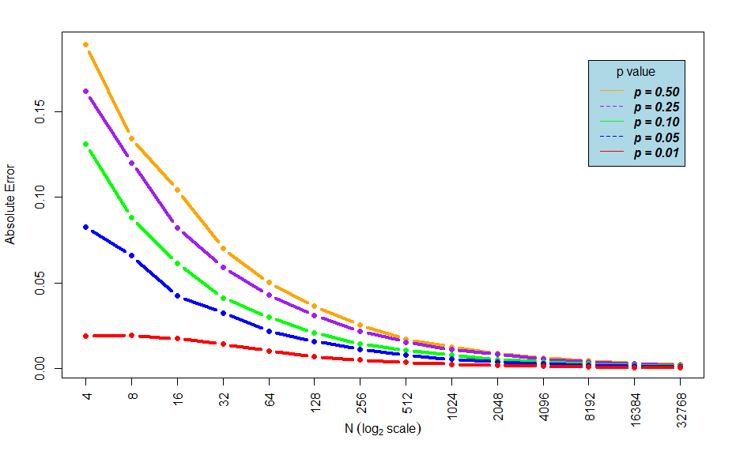

```r
legend(12, 0.18, legend=c("p = 0.50", "p = 0.25", "p = 0.10", "p = 0.05", "p = 0.01"),
       col=c("orange", "purple", "green", "blue", "red"), lty=1:2, cex=1,
       title="p value", text.font=4, bg='lightblue')
```

As for relative error, we can find that with N increase, error will decrease. And the larger the p value, the smaller error.

```r
plot(rel_error[1,1:14], col = "orange", type = "b", ylim = c(0,2), xaxt = "n", xlab = ("N"~(log[2]~"scale")), ylab = "Relative Error", pch=16, lwd = 4)
axis(1, at = 1:14, labels = label, las = 2)
```

```r
lines(rel_error[2,1:14], col = "purple", type = "b", pch=16, lwd = 4)
lines(rel_error[3,1:14], col = "green", type = "b", pch=16, lwd = 4)
```

```r
lines(rel_error[4,1:14], col = "blue", type = "b", pch=16, lwd = 4)
lines(rel_error[5,1:14], col = "red", type = "b", pch=16, lwd = 4)
```

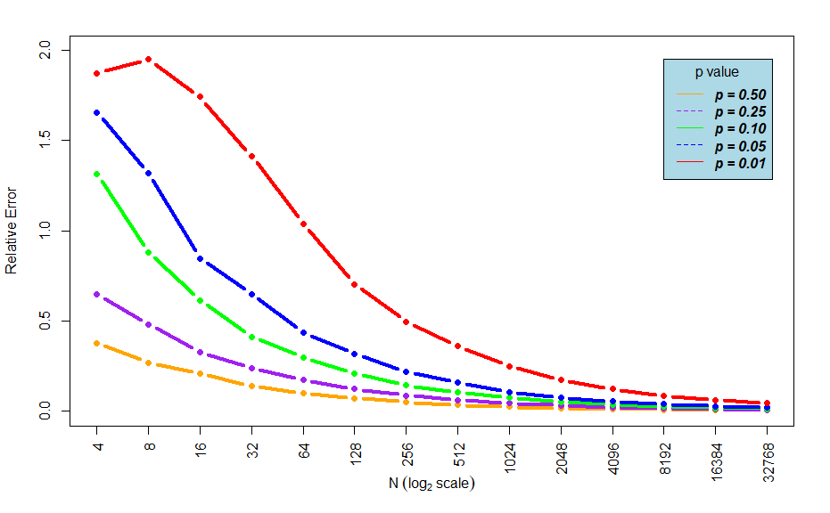

```r
legend(12, 1.95, legend=c("p = 0.50", "p = 0.25", "p = 0.10", "p = 0.05", "p = 0.01"),
       col=c("orange", "purple", "green", "blue", "red"), lty=1:2, cex=1,
       title="p value", text.font=4, bg='lightblue')
```

Then, I scale $log10$ to the y-axis. Let’s see what will happen.

```r
log_abs <- log10(abs_error)
label <- c(2^2, 2^3, 2^4, 2^5,2^6, 2^7, 2^8, 2^9, 2^10, 2^11, 2^12, 2^13, 2^14, 2^15)
plot(log_abs[1,1:14], col = "orange", type = "b", xaxt = "n", xlab = ("N"~(log[2]~"scale")), ylab = (log[10]~("Absolute Error")), ylim = c(-3.5, -0.5), pch=16, lwd = 4)
axis(1, at = 1:14, labels = label, las = 2)
```

```r
lines(log_abs[2,1:14], col = "purple", type = "b", pch=16, lwd = 4)
lines(log_abs[3,1:14], col = "green", type = "b", pch=16, lwd = 4)
```

```r
lines(log_abs[4,1:14], col = "blue", type = "b", pch=16, lwd = 4)
lines(log_abs[5,1:14], col = "red", type = "b", pch=16, lwd = 4)
```

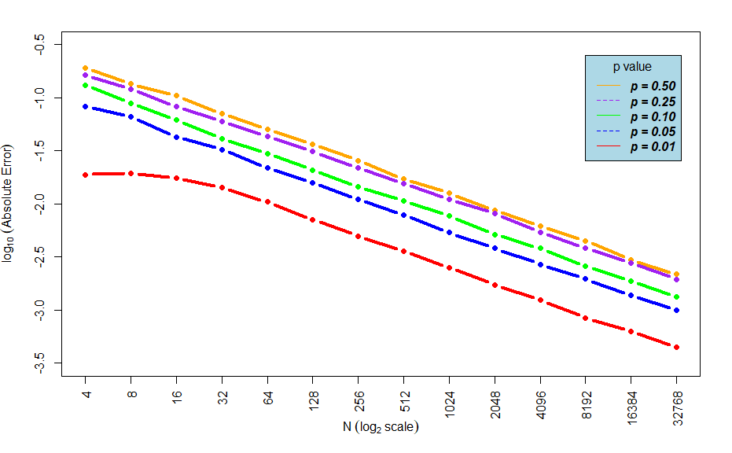

```r
legend(12, -0.6, legend=c("p = 0.50", "p = 0.25", "p = 0.10", "p = 0.05", "p = 0.01"),
       col=c("orange", "purple", "green", "blue", "red"), lty=1:2, cex=1,
       title="p value", text.font=4, bg='lightblue')
```

```r
log_rel <- log10(rel_error)
label <- c(2^2, 2^3, 2^4, 2^5,2^6, 2^7, 2^8, 2^9, 2^10, 2^11, 2^12, 2^13, 2^14, 2^15)
plot(log_rel[5,1:14], col = "red", type = "b", xaxt = "n", xlab = ("N"~(log[2]~"scale")), ylab = (log[10]~("Relative Error")), ylim = c(-2.5, 0.3), pch=16, lwd = 4)
axis(1, at = 1:14, labels = label, las = 2)
```

```r
lines(log_rel[4,1:14], col = "blue", type = "b", pch=16, lwd = 4)
lines(log_rel[3,1:14], col = "green", type = "b", pch=16, lwd = 4)
```

```r
lines(log_rel[2,1:14], col = "purple", type = "b", pch=16, lwd = 4)
lines(log_rel[1,1:14], col = "orange", type = "b", pch=16, lwd = 4)
```

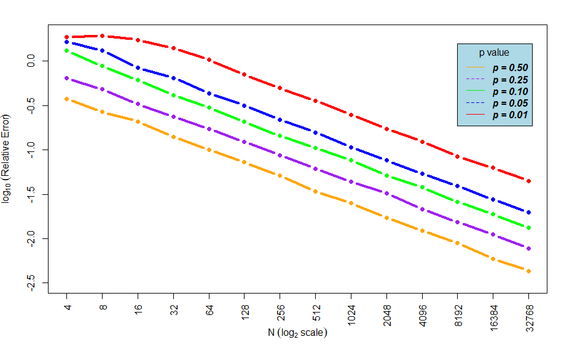

```r
legend(12, 0.2, legend=c("p = 0.50", "p = 0.25", "p = 0.10", "p = 0.05", "p = 0.01"),
       col=c("orange", "purple", "green", "blue", "red"), lty=1:2, cex=1,
       title="p value", text.font=4, bg='lightblue')
```

If we change y-axis is on the $log10$ scale, we can found that there is a liner relationship between Absolute error/Relative error and N.